# Hil1-2 repeats comparisons

Bin He

2022-01-12 Updated 26 January, 2022

```r
require(tidyverse)
require(cowplot)
require(ggtree)
require(treeio)
```

# Goal

- Investigate the evolutionary rates and selective forces acting on the PF11765 (NTD) portion of the Hil homologs, within the MDR clade.

# Approach

Use PAML to estimate the branch length and omega values for the different branches in the PF11765 tree. If initial results suggest different rates / constraints among the branches, move on to perform formal hypotheses testing.

# Data

# Analysis

## MDR, free or one ratios

```r
mdr.freeR <- read.codeml_mlc("../output/paml/MDR-PF11765/MDR-PF11765-freeR/mlc")
mdr.oneR <- read.codeml_mlc("../output/paml/MDR-PF11765/MDR-PF11765-oneR/mlc")
```

```r
mdr.freeR.1 <- drop.tip(mdr.freeR, tip = c("XP_462630.1_Dhansenii", "XP_002770057.1_Dhansenii"))
ggtree(mdr.freeR.1, aes(color = dN_vs_dS), branch.length = 'none', ) +
  geom_tiplab(as_ylab = TRUE, size = 7) +
  geom_text(data = td_filter(dN_vs_dS > 0.5),
            aes(x = branch, label = paste(round(dN, 2), round(dS, 2), sep = "/")),
            vjust = -.5, size = 2.5) +
  scale_color_continuous(name='dN/dS', limits=c(0, 1.5),
                         oob=scales::squish,
                         low='darkgreen', high='red')
```

```
existing scale.
```

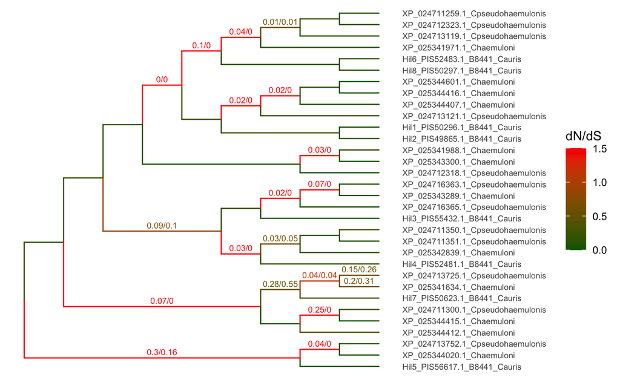

```r
ggsave("../output/figure/20220122-MDR-PF11765-freeR-anno-tree.png", width = 7, height = 4.5)
```

```
existing scale.
```

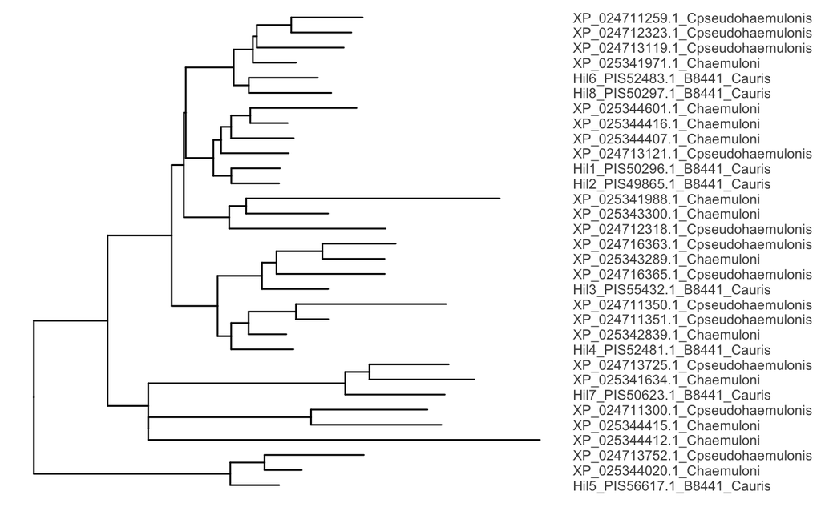

```r
mdr.oneR.1 <- drop.tip(mdr.oneR, tip = c("XP_462630.1_Dhansenii", "XP_002770057.1_Dhansenii"))
ggtree(mdr.oneR.1) +  geom_tiplab(as_ylab = TRUE)
```

## *C. auris* free ratio

I found how I specify the codonfreq parameter has a profound effect on the branch lengths estimates, and to some extent on the dN/dS estimates as well, where `CodonFreq=2` (F3x4) results in very large dS estimates and identified different branches as having elevated dN/dS than `CodonFreq=0/1` did.

### `CodonFreq = 0`

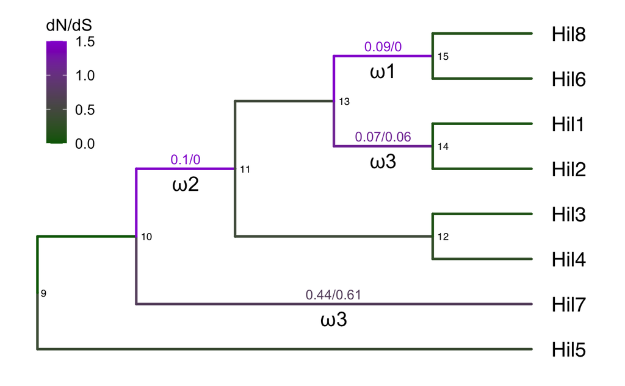

```r
caur.freeR.cf0 <- read.codeml_mlc("../output/paml/B8441-Hil1-8-PF11765/codonfreq0-freeR/mlc")

ggtree(caur.freeR.cf0, aes(color = dN_vs_dS), size = 1, branch.length = 'none') +
  #geom_rootedge(rootedge = 0.1) +
  geom_nodelab(hjust = -0.2, size = 3, color = "black") +
  geom_tiplab(aes(label = str_extract(label, "Hil[1-8]")), size = 6, hjust = -0.5, color = 1) +
  xlim(0, 5.6) +
  geom_text(data = td_filter(dN_vs_dS > 0.5),
            aes(x = branch, label = paste(round(dN, 2), round(dS, 2), sep = "/")),
            vjust = -.5, size = 4) +
  geom_text(data = td_filter(node == 15), aes(x = branch, label = "ω1"),
            vjust = 1.5, size = 6, color = "black") +
  geom_text(data = td_filter(node == 11), aes(x = branch, label = "ω2"),
            vjust = 1.5, size = 6, color = "black") +
  geom_text(data = td_filter(node %in% c(4, 14)), aes(x = branch, label = "ω3"),
            vjust = 1.5, size = 6, color = "black") +
  scale_color_continuous(name='dN/dS', limits=c(0, 1.5),
                         oob=scales::squish, low='darkgreen', high="darkviolet") +
  theme(legend.position = c(0.1,0.8), legend.text = element_text(size = 12),
        legend.title = element_text(size = 14))
ggsave("../output/figure/20220122-caur-PF11765-Feual-freeR-anno-tree.png", width = 5, height = 5)
```

### `CodonFreq = 1`

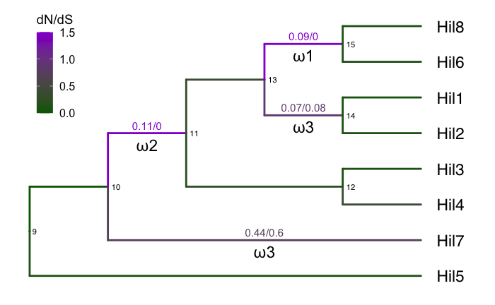

```r
caur.freeR.cf1 <- read.codeml_mlc("../output/paml/B8441-Hil1-8-PF11765/codonfreq1-freeR/mlc")
ggtree(caur.freeR.cf1, aes(color = dN_vs_dS), size = 1, branch.length = 'none') +
  #geom_rootedge(rootedge = 0.1) +
  geom_nodelab(hjust = -0.2, size = 3, color = "black") +
  geom_tiplab(aes(label = str_extract(label, "Hil[1-8]")), size = 6, hjust = -0.5, color = 1) +
  xlim(0, 5.6) +
  geom_text(data = td_filter(dN_vs_dS > 0.5),
            aes(x = branch, label = paste(round(dN, 2), round(dS, 2), sep = "/")),
            vjust = -.5, size = 4) +
  geom_text(data = td_filter(node == 15), aes(x = branch, label = "ω1"),
            vjust = 1.5, size = 6, color = "black") +
  geom_text(data = td_filter(node == 11), aes(x = branch, label = "ω2"),
            vjust = 1.5, size = 6, color = "black") +
  geom_text(data = td_filter(node %in% c(4, 14)), aes(x = branch, label = "ω3"),
            vjust = 1.5, size = 6, color = "black") +
  scale_color_continuous(name='dN/dS', limits=c(0, 1.5),
                         oob=scales::squish, low='darkgreen', high="darkviolet") +
  theme(legend.position = c(0.1,0.8), legend.text = element_text(size = 12),
        legend.title = element_text(size = 14))
ggsave("../output/figure/20220122-caur-PF11765-F1x4-freeR-anno-tree.png", width = 5, height = 5)
```

### `CodonFreq = 2`

Plotted as cladogram to avoid compressing some of the lineages. Branch lengths are printed at the bottom of the branches.

```
Warning: Removed 1 rows containing missing values (geom_text).
```

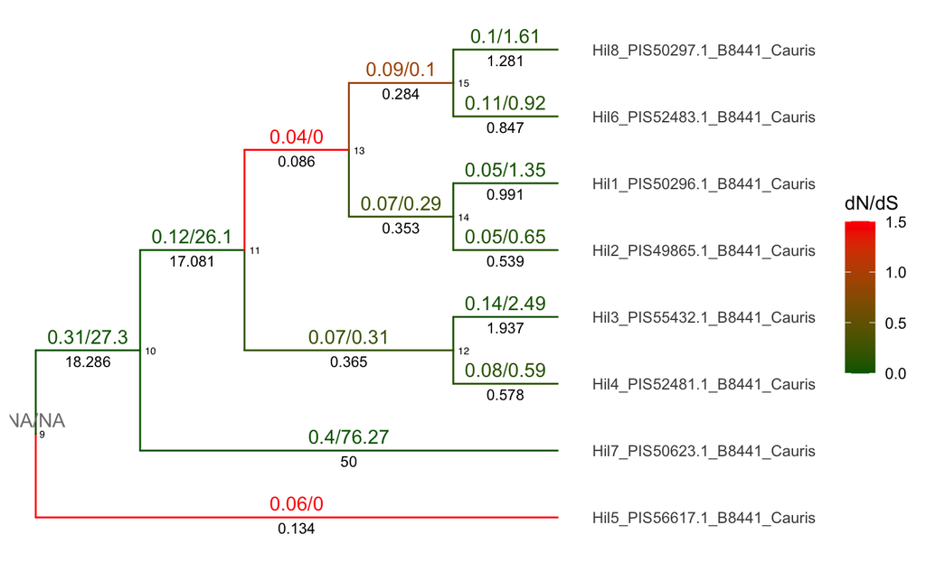

```r
caur.freeR.cf2 <- read.codeml_mlc("../output/paml/B8441-Hil1-8-PF11765-freeR-codonfreq2/mlc")
# several internal branches have 0 inferred syn or nonsyn changes, and the dN/dS ratio estimates doesn't make much sense
ggtree(caur.freeR.cf2, aes(color = dN_vs_dS), branch.length = 'none') +
  #geom_rootedge(rootedge = 0.1) +
  geom_nodelab(hjust = -0.2, size = 2, color = "black") +
  geom_tiplab(as_ylab = TRUE) +
  geom_text(aes(x = branch, label = paste(round(dN, 2), round(dS, 2), sep = "/")), vjust = -.5) +
  geom_text(aes(x = branch, label = round(t, 3)), vjust = 1.5, color = "black", size = 3) +
  scale_color_continuous(name='dN/dS', limits=c(0, 1.5),
                         oob=scales::squish,
                         low='darkgreen', high='red')
```